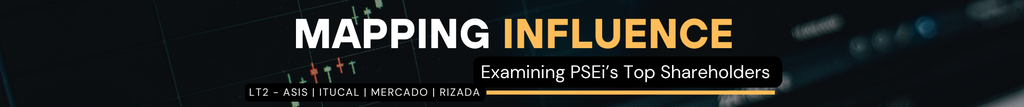

# Introduction

The Philippine Stock Exchange Index (PSEi) represents the top 30 publicly listed companies on the Philippine Stock Exchange, showcasing the most significant players by market capitalization. To promote transparency, listed companies are mandated to disclose their top 100 shareholders quarterly. This regulation sheds light on key stakeholders, including individual investors, institutional entities, and offshore institutions, whose significant voting power influences corporate policies.

This report leverages network science to analyze shareholder connections and identify the top movers shaping the local stock exchange. By mapping these relationships, we aim to provide deeper insights into the forces driving the PSEi and the broader investment landscape.

# Problem Statement and Significance

How do the top shareholders of PSEi-listed companies connect, and how do these relationships shape market dynamics? By analyzing these connections, we can uncover power dynamics and influence patterns that drive decision-making and impact the Philippine stock market. Understanding these networks is critical to gaining insights into market behavior and shareholder influence.

# Methodology

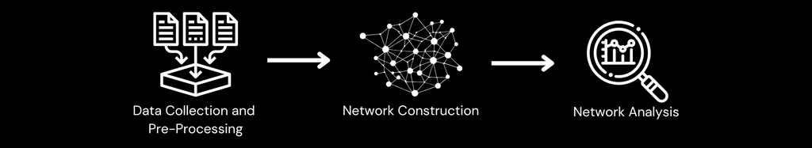

## Dataset Overview

The dataset comprises a list of the top 100 stockholders for PSEi-listed companies from 2019 to 2024. It includes key attributes such as shareholder names, investor types (e.g., individual, institutional, offshore), and the number of outstanding shares held. The data is sourced from reputable platforms like PSE Edge and Bloomberg, ensuring accuracy and transparency.

In this network analysis, nodes represent stockholders, while links signify co-ownership between shareholders across different companies. By examining these connections, we can explore patterns of influence, ownership overlaps, and the dynamics of shareholder relationships within the Philippine stock market.

## Top 100 PSEi Shareholder Network Ownership 2019-2024

```python
from helper import *
import warnings
warnings.filterwarnings("ignore")
```

[output not shown]

```python
df = prep_df1()
```

**Bipartite Views**

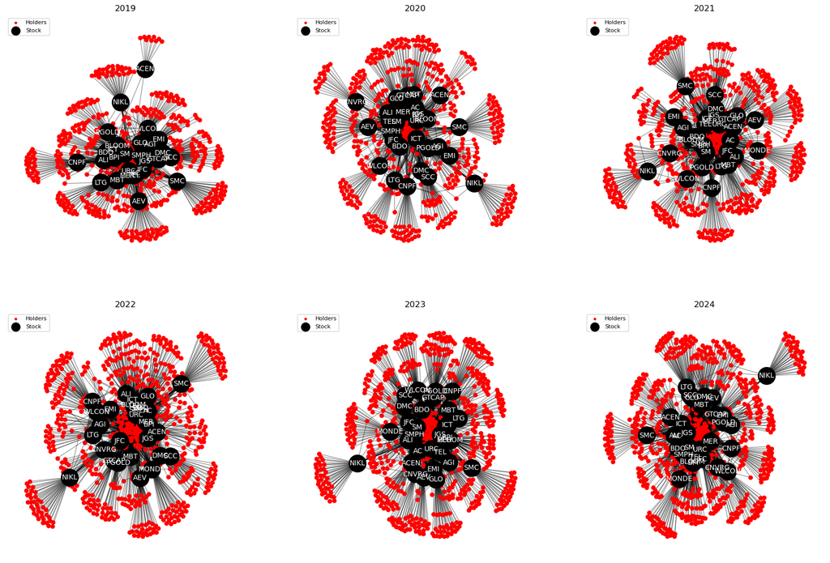

```python
display(make_bip_net_graph(df))
```

**2024 - Holder-Holder - Projection**

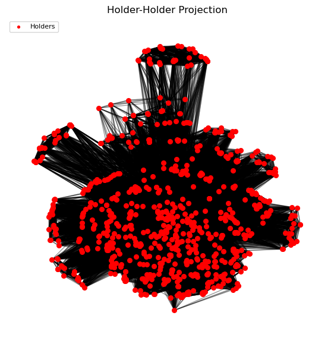

**Network Statistics**

|  | Metric | Value |
| --- | --- | --- |
| 0 | Nodes | 764 |
| 1 | Edges | 53593 |

**Degree Distribution**

|  | Metric | Value |
| --- | --- | --- |
| 0 | Minimum Degree | 23.000 |
| 1 | Maximum Degree | 763.000 |
| 2 | Average Degree | 140.296 |

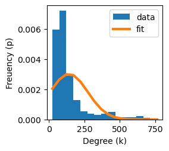

**Shortest Paths**

```
Average shortest path length: 1.816
```

**Clustering Coefficient**

```
average clustering coefficient: 0.869
```

**Holder-Holder Stats**

|  | id | degree Centrality | id | betweenness Centrality | id | closeness Centrality | id | pagerank Centrality |
| --- | --- | --- | --- | --- | --- | --- | --- | --- |
| 0 | Dimensional Fund Advisors LP | 1.000000 | Dimensional Fund Advisors LP | 0.044898 | Dimensional Fund Advisors LP | 1.000000 | Dimensional Fund Advisors LP | 0.007050 |
| 1 | State Street Corp | 0.956750 | American Century Cos Inc | 0.034979 | State Street Corp | 0.958543 | State Street Corp | 0.006507 |
| 2 | American Century Cos Inc | 0.933159 | State Street Corp | 0.030021 | American Century Cos Inc | 0.937346 | American Century Cos Inc | 0.006462 |

```python
final_summary(df)
```

Offshore institutional investors emerge as the most influential shareholders, reflecting their significant role in shaping the Philippine stock market. This dominance highlights the substantial impact of foreign ownership on corporate policies and market dynamics.

## Local Ownership Insights

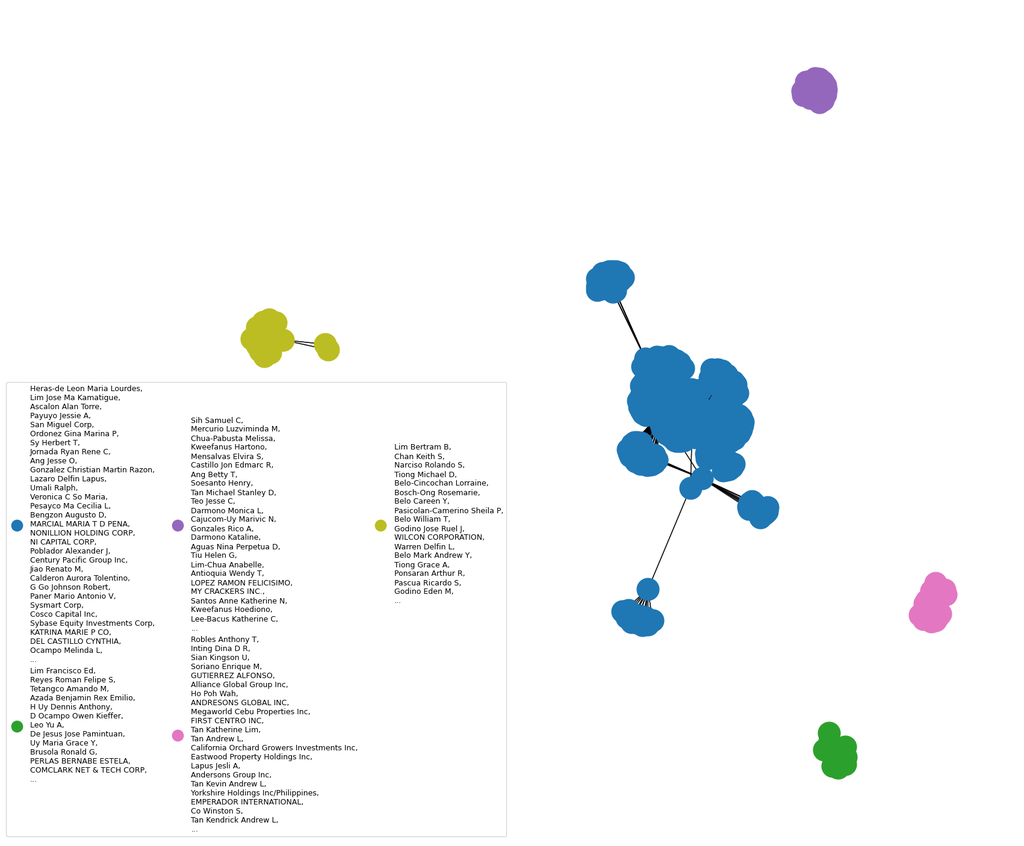

```python
df, df100mn = prep_df2()
local_ownership(df, df100mn)
```

Local direct ownership, excluding shares under the Philippine Depository and Trust Corporation (PDC), presents a fragmented and disconnected structure within the PSEi network. The ownership is primarily organized into small clusters or isolated groups, often connected through specific sectors. These local stakeholders exert limited influence across the broader market, with their impact being more sector-specific rather than widespread throughout the entire PSEi.

**Holder-Holder Stats**

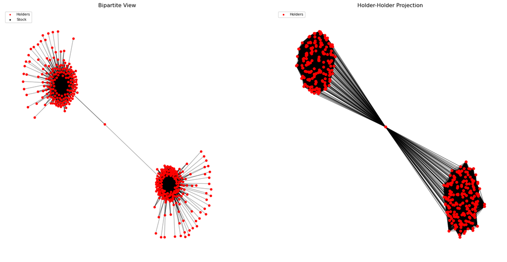

**Network Statistics**

|  | Metric | Value |
| --- | --- | --- |
| 0 | Nodes | 377 |
| 1 | Edges | 33606 |

**Degree Distribution**

|  | Metric | Value |
| --- | --- | --- |
| 0 | Minimum Degree | 111.000 |
| 1 | Maximum Degree | 298.000 |
| 2 | Average Degree | 178.281 |

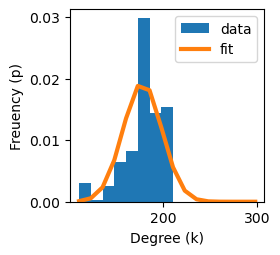

**Shortest Paths**

```
Average shortest path length: 1.724
```

**Clustering Coefficient**

```
average clustering coefficient: 0.961
```

|  | id | degree Centrality | id | betweenness Centrality | id | closeness Centrality | id | pagerank Centrality |
| --- | --- | --- | --- | --- | --- | --- | --- | --- |
| 0 | BENJAMIN CO CA & CO., INC. | 0.792553 | BENJAMIN CO CA & CO., INC. | 0.499295 | BENJAMIN CO CA & CO., INC. | 0.828194 | BENJAMIN CO CA & CO., INC. | 0.004178 |
| 1 | FIDELITY SECURITIES, INC. | 0.531915 | FIDELITY SECURITIES, INC. | 0.001476 | FIDELITY SECURITIES, INC. | 0.664311 | FIDELITY SECURITIES, INC. | 0.002851 |
| 2 | TANSENGCO & CO., INC. | 0.531915 | TANSENGCO & CO., INC. | 0.001476 | TANSENGCO & CO., INC. | 0.664311 | TANSENGCO & CO., INC. | 0.002851 |

```python
pdc()
```

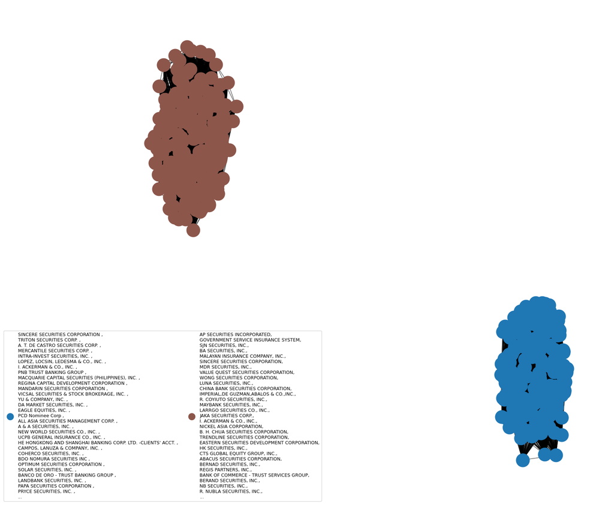

```python
pdc_communities()
```

## PDC Insights

The Philippine Depository & Trust Corporation (PDC) plays a crucial role as a custodian, holding shares on behalf of numerous investors. In the holder-holder projection, PDC's structure reveals a highly interconnected network.

**Network Statistics**:

- Nodes: 377
- Edges: 33,606
- Degree Range: 111 to 298
- Average Degree: 178.28
- Average Shortest Path Length: 1.7
- Average Clustering Coefficient: 0.96

These metrics indicate a densely connected network with strong cohesion among nodes, as shown by the high clustering coefficient. The relatively short average path length of 1.7 suggests that, despite the network's size, most nodes are closely interconnected.

**Centrality Measures**

The centrality analysis identifies Benjamin Co Ca & Co. Inc. as a prominent player within the network, with the following scores:

- Degree: 0.792
- Betweenness: 0.499
- Closeness: 0.828
- Pagerank: 0.004

These centrality measures indicate that Benjamin Co Ca & Co. Inc. holds significant influence in terms of connectivity, intermediating between different parts of the network and having a prominent position in the holder-holder structure.

**Additional Insights**

# Key Findings

Top 100 shareholders PSEi Network Insights The full PSEi network reveals key dynamics in shareholder influence:

- **Offshore Institutions**: Offshore institutions emerge as dominant influencers within the network, showcasing high connectivity and substantial impact on market decisions.
- **Local Investors**: Excluding shares held under the Philippine Depository & Trust Corporation (PDC), local investors are more isolated, contributing to a fragmented network with disconnected clusters.
- **Limited Influence**: Local investors, particularly those outside PDC-held shares, display limited influence across the broader PSEi network.
- **PDC Holdings**: In contrast, holdings under the PDC exhibit a well-connected, tightly knit structure with high clustering, indicating stronger cohesion and centralized influence within this group.

# Recommendations

1. **Expand Scope**:  
   To gain a more comprehensive understanding of the market dynamics, it is recommended to expand the scope of the analysis to include non-index companies. This will provide a clearer picture of the broader shareholder landscape and uncover additional influences that may be at play outside the top 30 listed firms.
2. **Sector-Specific Analyses**:  
   Given the interconnectedness within sectors, performing sector-specific analyses can uncover distinct patterns of ownership and influence. This approach will highlight how investors within specific industries interact and how their shareholding impacts market movements within those sectors.
3. **Consider Weighted Networks**:  
   To enhance the accuracy of the network analysis, consider using weighted networks. This would involve applying weights to edges based on the volume or value of shares held, rather than treating all relationships equally. This approach would reflect the true financial influence of shareholders.
4. **Use Nominal PHP Values**:  
   Incorporating the nominal Philippine Peso (PHP) values of holdings as weights will provide a more precise measure of shareholder influence. By accounting for the actual financial value of each shareholder's stake, the analysis can better capture the economic impact that major shareholders have on the market.